# Group 2 Fourth Markdown Project

# Discussion

Results from linear regression exhibit that there is a relationship between each of the variables being studied (grade level, the types of bullying experienced: being made fun of and spreading of rumors) as seen in the best fit lines shown in the graphs.

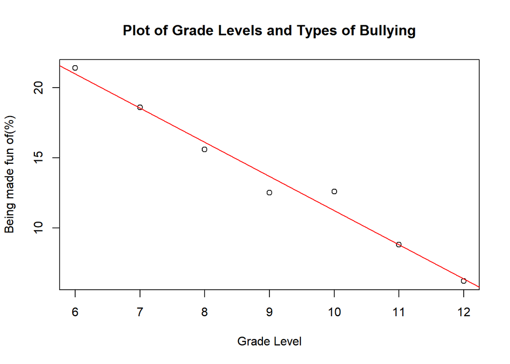

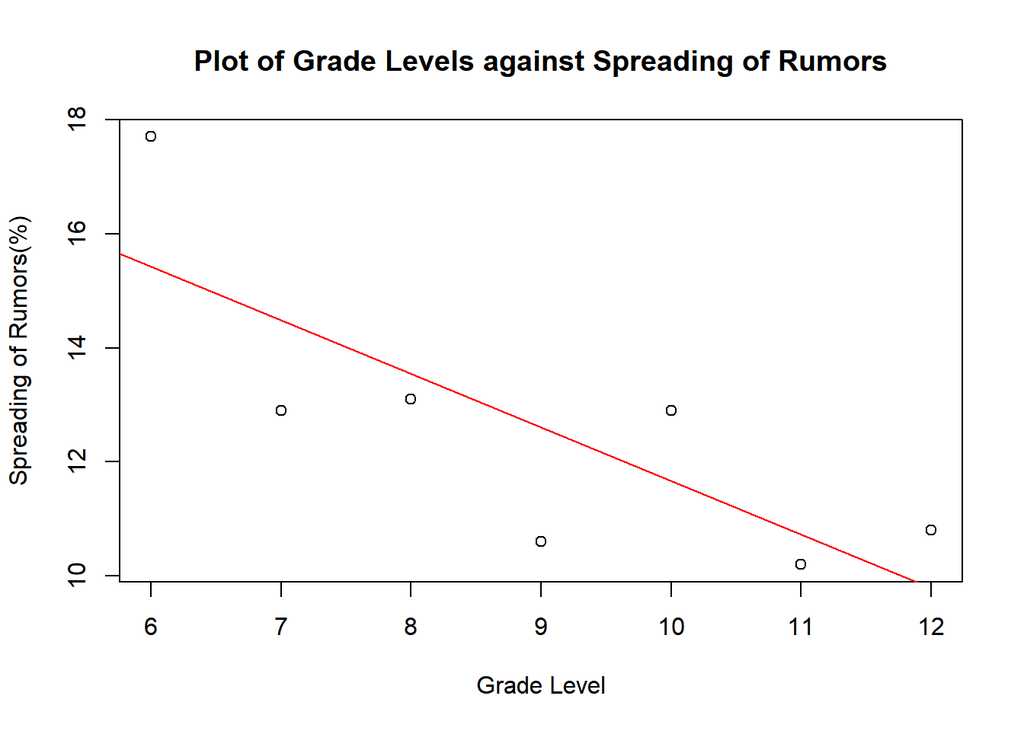

It can be seen that there is a general downward trend in the second and third graphs indicating that bullying decreases as the grade level increases or as the students get older. This is supported by a study stating that verbal bullying is the most common form of bullying and that the majority of the occurences of bullying occurs in secondary schools.

The trend of younger students experiencing more bullying than higher level students may be explained by power imbalances in relationships between people. In instances of bullying, the bully tends to be the person with higher position or power compared to the one being bullied. This power imbalance is also what causes bullies to repeatedly bully, having the power to do so.

This information tells us that there is a need of higher attention to bullying especially to the ones involving younger kids. In school grounds, students must always be supervised by teachers in order to prevent occurrences of bullying. Doing so will be a step towards creating a better environment for children to learn and grow.

# Conclusion

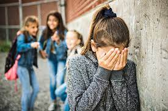

To conclude, bullying is a big problem, especially in modern day schooling. Bullying normally starts from something small and evolves into bigger and physically harmful deeds. Identifying the relationship between two types of bullying can help people realize how bullying can get worse if there is no intervention.

The upward trend between the two types of bullying in the data set shows that there is an increase in bullying between being made fun of and spreading rumors. As the bullying escalates, the number of people being bullied also increases.

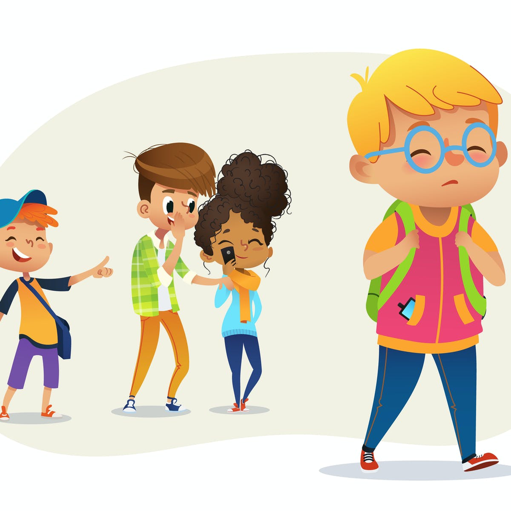

There is a noticeable decline in the number of students bullied as grade levels increase. On paper, this indicates lesser bullying as students get older. However, the researchers believe that the decrease in reported bullying cases is due to students not wanting to admit that they are being bullied in school. This is understandable since some people refuse to openly share about their experience being bullied.

As for the values of $\sigma^2$ and the standard errors of regression coefficients, we can use these in further testing or to support our present data. The low p-value of the being made fun of variable in the table of Summary 1 tells us that this variable is significant.